# Employee attrition

Maria Leszczynska

2025-01-16

## Employee attrition is a significant challenge for organizations, impacting productivity, morale, and overall business performance. This analysis explores various factors related to employee turnover, helping identify key patterns and potential strategies for retention.

### Loading in the data and having a look

```
## Rows: 1,470
## Columns: 35
## $ Age                      <int> 41, 49, 37, 33, 27, 32, 59, 30, 38, 36, 35, 2…
## $ Attrition                <chr> "Yes", "No", "Yes", "No", "No", "No", "No", "…
## $ BusinessTravel           <chr> "Travel_Rarely", "Travel_Frequently", "Travel…
## $ DailyRate                <int> 1102, 279, 1373, 1392, 591, 1005, 1324, 1358,…
## $ Department               <chr> "Sales", "Research & Development", "Research …
## $ DistanceFromHome         <int> 1, 8, 2, 3, 2, 2, 3, 24, 23, 27, 16, 15, 26, …
## $ Education                <int> 2, 1, 2, 4, 1, 2, 3, 1, 3, 3, 3, 2, 1, 2, 3, …
## $ EducationField           <chr> "Life Sciences", "Life Sciences", "Other", "L…
## $ EmployeeCount            <int> 1, 1, 1, 1, 1, 1, 1, 1, 1, 1, 1, 1, 1, 1, 1, …
## $ EmployeeNumber           <int> 1, 2, 4, 5, 7, 8, 10, 11, 12, 13, 14, 15, 16,…
## $ EnvironmentSatisfaction  <int> 2, 3, 4, 4, 1, 4, 3, 4, 4, 3, 1, 4, 1, 2, 3, …
## $ Gender                   <chr> "Female", "Male", "Male", "Female", "Male", "…
## $ HourlyRate               <int> 94, 61, 92, 56, 40, 79, 81, 67, 44, 94, 84, 4…
```

[output cut: 22 more lines]

```
##       Age         Attrition         BusinessTravel       DailyRate
##  Min.   :18.00   Length:1470        Length:1470        Min.   : 102.0
##  1st Qu.:30.00   Class :character   Class :character   1st Qu.: 465.0
##  Median :36.00   Mode  :character   Mode  :character   Median : 802.0
##  Mean   :36.92                                         Mean   : 802.5
##  3rd Qu.:43.00                                         3rd Qu.:1157.0
##  Max.   :60.00                                         Max.   :1499.0
##   Department        DistanceFromHome   Education     EducationField
##  Length:1470        Min.   : 1.000   Min.   :1.000   Length:1470
##  Class :character   1st Qu.: 2.000   1st Qu.:2.000   Class :character
##  Mode  :character   Median : 7.000   Median :3.000   Mode  :character
##                     Mean   : 9.193   Mean   :2.913
##                     3rd Qu.:14.000   3rd Qu.:4.000
##                     Max.   :29.000   Max.   :5.000
##  EmployeeCount EmployeeNumber   EnvironmentSatisfaction    Gender
##  Min.   :1     Min.   :   1.0   Min.   :1.000           Length:1470
##  1st Qu.:1     1st Qu.: 491.2   1st Qu.:2.000           Class :character
##  Median :1     Median :1020.5   Median :3.000           Mode  :character
##  Mean   :1     Mean   :1024.9   Mean   :2.722
##  3rd Qu.:1     3rd Qu.:1555.8   3rd Qu.:4.000
##  Max.   :1     Max.   :2068.0   Max.   :4.000
##    HourlyRate     JobInvolvement    JobLevel       JobRole
##  Min.   : 30.00   Min.   :1.00   Min.   :1.000   Length:1470
##  1st Qu.: 48.00   1st Qu.:2.00   1st Qu.:1.000   Class :character
##  Median : 66.00   Median :3.00   Median :2.000   Mode  :character
##  Mean   : 65.89   Mean   :2.73   Mean   :2.064
##  3rd Qu.: 83.75   3rd Qu.:3.00   3rd Qu.:3.000
##  Max.   :100.00   Max.   :4.00   Max.   :5.000
##  JobSatisfaction MaritalStatus      MonthlyIncome    MonthlyRate
##  Min.   :1.000   Length:1470        Min.   : 1009   Min.   : 2094
##  1st Qu.:2.000   Class :character   1st Qu.: 2911   1st Qu.: 8047
##  Median :3.000   Mode  :character   Median : 4919   Median :14236
##  Mean   :2.729                      Mean   : 6503   Mean   :14313
##  3rd Qu.:4.000                      3rd Qu.: 8379   3rd Qu.:20462
##  Max.   :4.000                      Max.   :19999   Max.   :26999
##  NumCompaniesWorked    Over18            OverTime         PercentSalaryHike
##  Min.   :0.000      Length:1470        Length:1470        Min.   :11.00
##  1st Qu.:1.000      Class :character   Class :character   1st Qu.:12.00
##  Median :2.000      Mode  :character   Mode  :character   Median :14.00
##  Mean   :2.693                                            Mean   :15.21
```

[output cut: 8 more lines]

```
##  Max.   :4.000     Max.   :4.000            Max.   :80    Max.   :3.0000
##  TotalWorkingYears TrainingTimesLastYear WorkLifeBalance YearsAtCompany
##  Min.   : 0.00     Min.   :0.000         Min.   :1.000   Min.   : 0.000
##  1st Qu.: 6.00     1st Qu.:2.000         1st Qu.:2.000   1st Qu.: 3.000
##  Median :10.00     Median :3.000         Median :3.000   Median : 5.000
##  Mean   :11.28     Mean   :2.799         Mean   :2.761   Mean   : 7.008
##  3rd Qu.:15.00     3rd Qu.:3.000         3rd Qu.:3.000   3rd Qu.: 9.000
##  Max.   :40.00     Max.   :6.000         Max.   :4.000   Max.   :40.000
##  YearsInCurrentRole YearsSinceLastPromotion YearsWithCurrManager
##  Min.   : 0.000     Min.   : 0.000          Min.   : 0.000
##  1st Qu.: 2.000     1st Qu.: 0.000          1st Qu.: 2.000
##  Median : 3.000     Median : 1.000          Median : 3.000
##  Mean   : 4.229     Mean   : 2.188          Mean   : 4.123
##  3rd Qu.: 7.000     3rd Qu.: 3.000          3rd Qu.: 7.000
##  Max.   :18.000     Max.   :15.000          Max.   :17.000
```

```
##  [1] "Age"                      "Attrition"
##  [3] "BusinessTravel"           "DailyRate"
##  [5] "Department"               "DistanceFromHome"
##  [7] "Education"                "EducationField"
##  [9] "EmployeeCount"            "EmployeeNumber"
## [11] "EnvironmentSatisfaction"  "Gender"
## [13] "HourlyRate"               "JobInvolvement"
## [15] "JobLevel"                 "JobRole"
## [17] "JobSatisfaction"          "MaritalStatus"
## [19] "MonthlyIncome"            "MonthlyRate"
## [21] "NumCompaniesWorked"       "Over18"
## [23] "OverTime"                 "PercentSalaryHike"
## [25] "PerformanceRating"        "RelationshipSatisfaction"
## [27] "StandardHours"            "StockOptionLevel"
## [29] "TotalWorkingYears"        "TrainingTimesLastYear"
## [31] "WorkLifeBalance"          "YearsAtCompany"
## [33] "YearsInCurrentRole"       "YearsSinceLastPromotion"
## [35] "YearsWithCurrManager"
```

```
##   Age Attrition BusinessTravel DailyRate Department DistanceFromHome Education
## 1   0         0              0         0          0                0         0
##   EducationField EmployeeCount EmployeeNumber EnvironmentSatisfaction Gender
## 1              0             0              0                       0      0
##   HourlyRate JobInvolvement JobLevel JobRole JobSatisfaction MaritalStatus
## 1          0              0        0       0               0             0
##   MonthlyIncome MonthlyRate NumCompaniesWorked Over18 OverTime
## 1             0           0                  0      0        0
##   PercentSalaryHike PerformanceRating RelationshipSatisfaction StandardHours
## 1                 0                 0                        0             0
##   StockOptionLevel TotalWorkingYears TrainingTimesLastYear WorkLifeBalance
## 1                0                 0                     0               0
##   YearsAtCompany YearsInCurrentRole YearsSinceLastPromotion
## 1              0                  0                       0
##   YearsWithCurrManager
## 1                    0
```

```
##   Age Attrition    BusinessTravel DailyRate             Department
## 1  41       Yes     Travel_Rarely      1102                  Sales
## 2  49        No Travel_Frequently       279 Research & Development
## 3  37       Yes     Travel_Rarely      1373 Research & Development
## 4  33        No Travel_Frequently      1392 Research & Development
## 5  27        No     Travel_Rarely       591 Research & Development
## 6  32        No Travel_Frequently      1005 Research & Development
##   DistanceFromHome Education EducationField EmployeeCount EmployeeNumber
## 1                1         2  Life Sciences             1              1
## 2                8         1  Life Sciences             1              2
## 3                2         2          Other             1              4
## 4                3         4  Life Sciences             1              5
## 5                2         1        Medical             1              7
## 6                2         2  Life Sciences             1              8
##   EnvironmentSatisfaction Gender HourlyRate JobInvolvement JobLevel
```

[output cut: 41 more lines]

## Why do employees leave?

### Understanding the age distribution of employees can tell us whether certain age groups are more likely to leave the company:

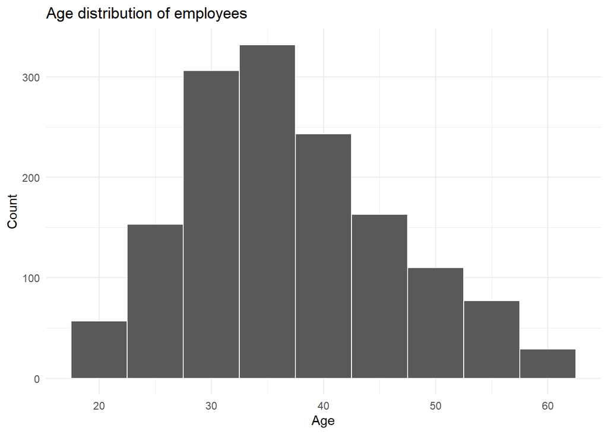

We can see that largest age group of employees is 28-45 years old.

### Age distribution by attrition:

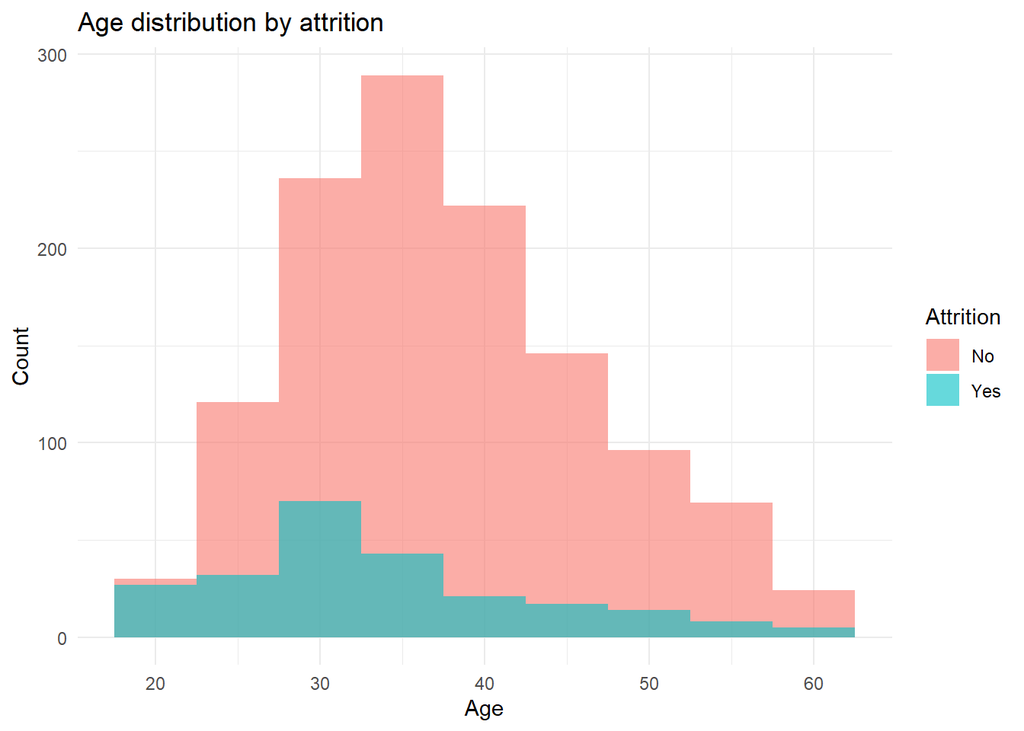

We can see here that young people are more likely to leave the company. This makes sense as they are in the early stages of their careers and want opportunities for growth. I believe this might be the case as the “work culture” has shifted quite a bit and younger workers have a higher standard/expectation regarding the company culture and job satisfaction compared to older employees.

### Let’s have a look at gender distribution. It helps us understand the gender balance in the company, which may influence attrition trends:

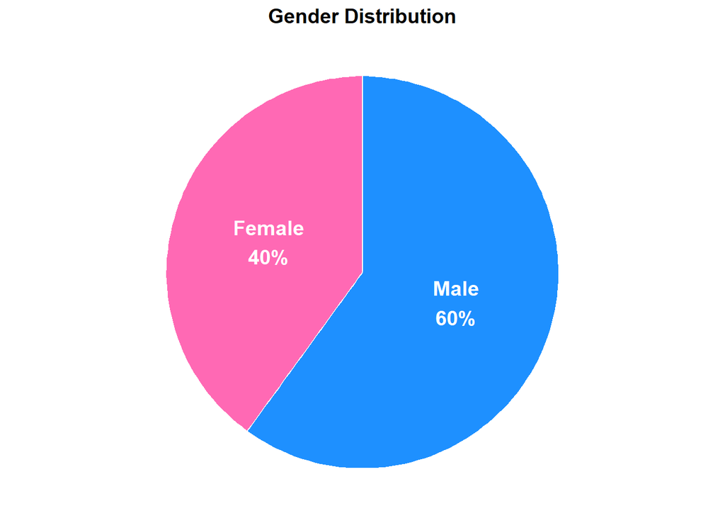

We can see that the genders are fairly balanced at 40/60 women to men proportion, which suggest that the company cares about diversity and the workplace being inclusive.

### Vertical stacked bar chart of gender distribution instead of a pie chart:

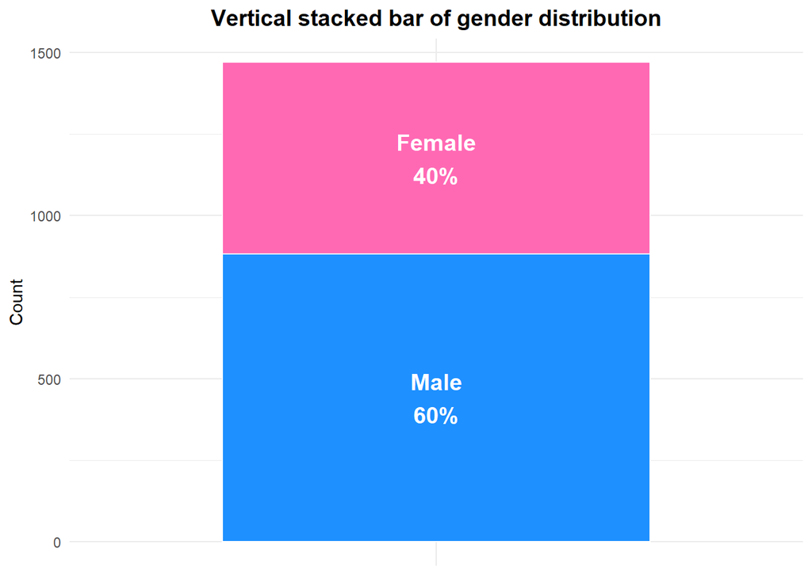

It conveys the same information as the pie chart, but it might be more readable for some people.

### Is one gender more likely to leave the company? Let’s now examine if there’s a noticeable difference in attrition rates between genders:

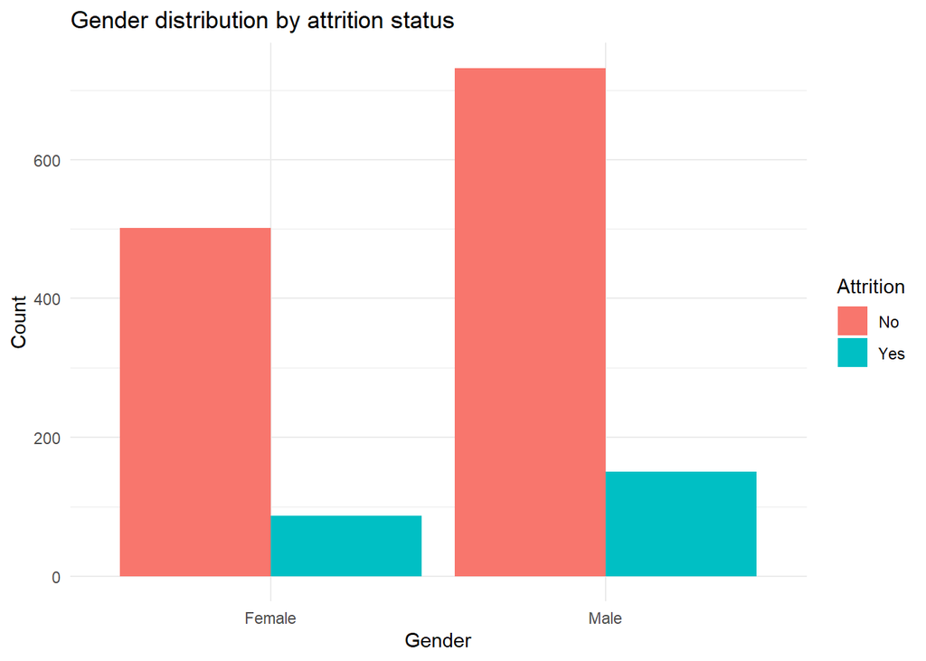

There isn’t a significant difference between the rate at which men and women leave the company, so employee attirition might not be gender related at all at this company.

### Density plot showing the age distribution for men and women:

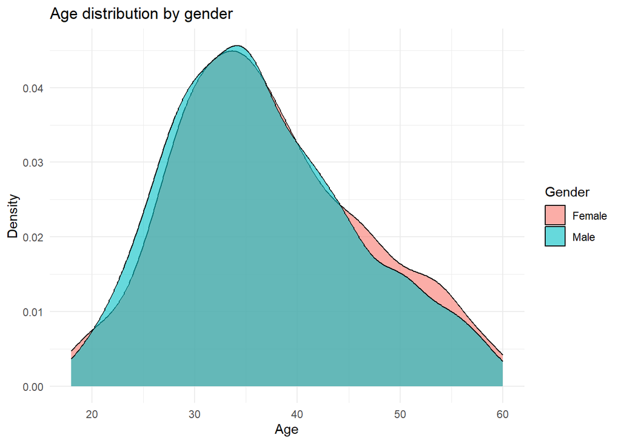

Just to be sure, we visualise the density plot for both genders and their ages to see if there are any biases in hiring. It is balanced, so we know there are no policies like hiring prediminantly older women.

### We can look at how age varies across different job roles within the organization. It helps identify if certain job roles are more likely to have younger or older employees:

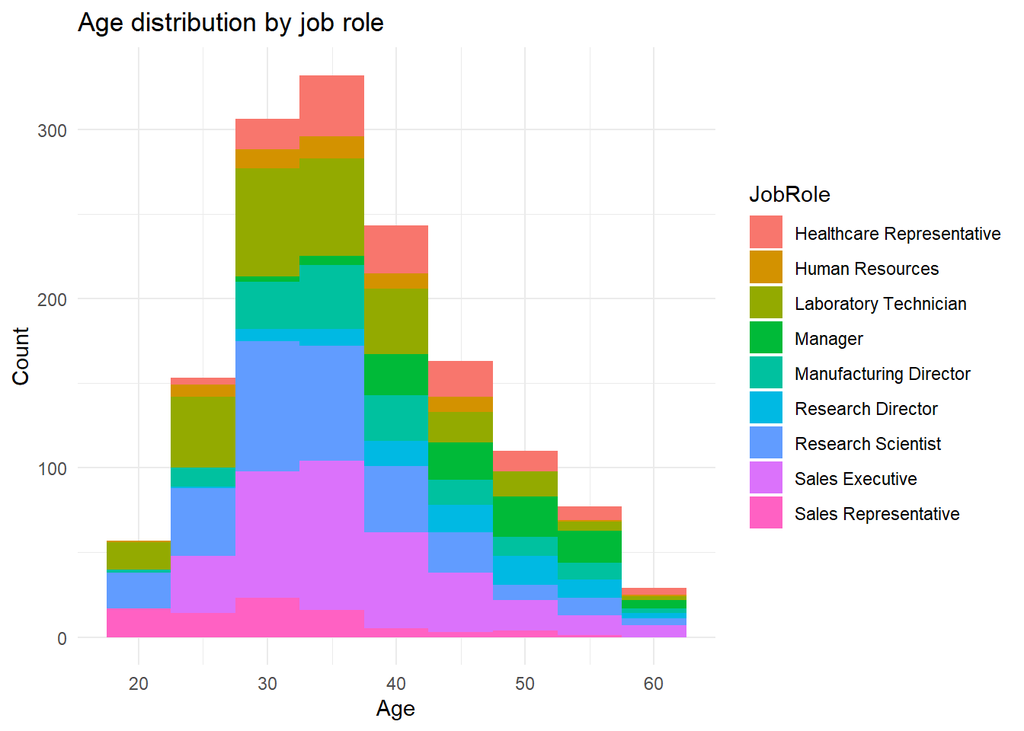

The data shows that sales executives, sales representatives, and laboratory technicians are primarily young employees. To understand the implications, we should analyze whether these roles have higher or lower turnover rates.

### Let’s have a look at the distribution of employees across different job roles and departments:

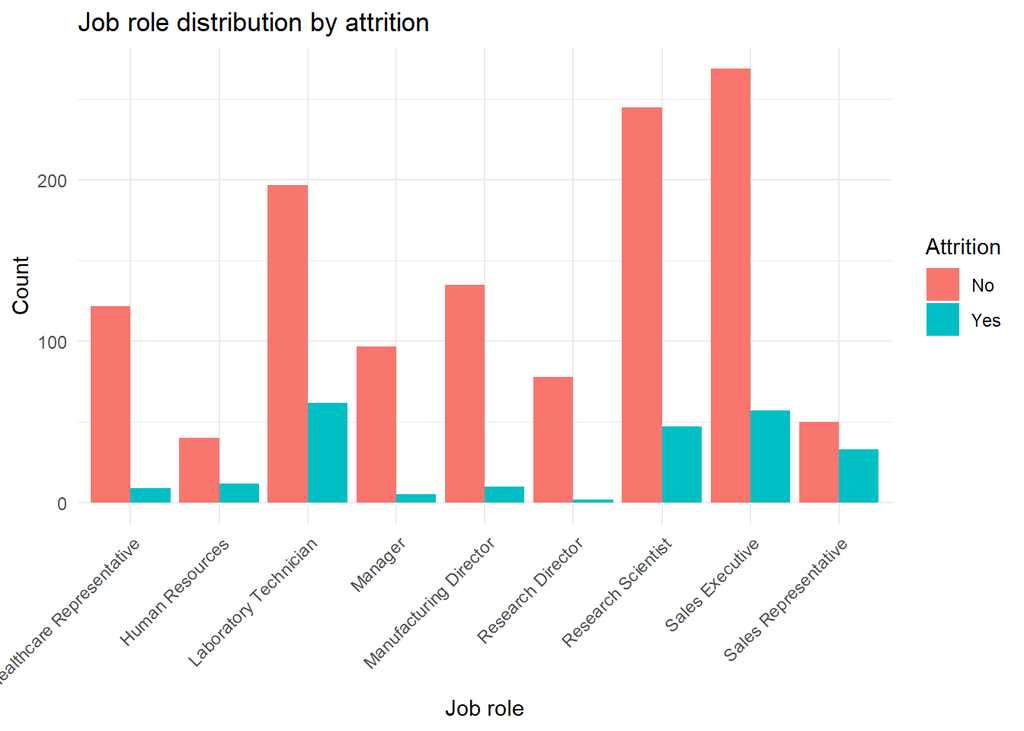

Young employees dominate roles like sales executives, sales representatives, and laboratory technicians, and these positions also show higher attrition rates. This could indicate challenges in retention, possibly due to job demands, career growth opportunities, or workplace conditions

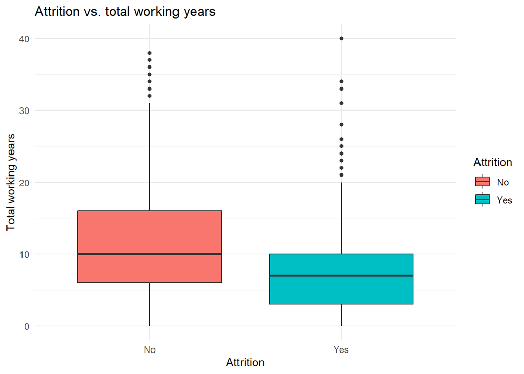

### To explore deeper relationships, we can investigate the correlation between age, monthly income, and years at the company, which may help explain trends in attrition:

```
##                      Age MonthlyIncome YearsAtCompany
## Age            1.0000000     0.4978546      0.3113088
## MonthlyIncome  0.4978546     1.0000000      0.5142848
## YearsAtCompany 0.3113088     0.5142848      1.0000000
```

I was expecting high positive correlation here, but I was suprised to see only medium positive correlation at most.

### Are employees with a long commute more likely to leave?

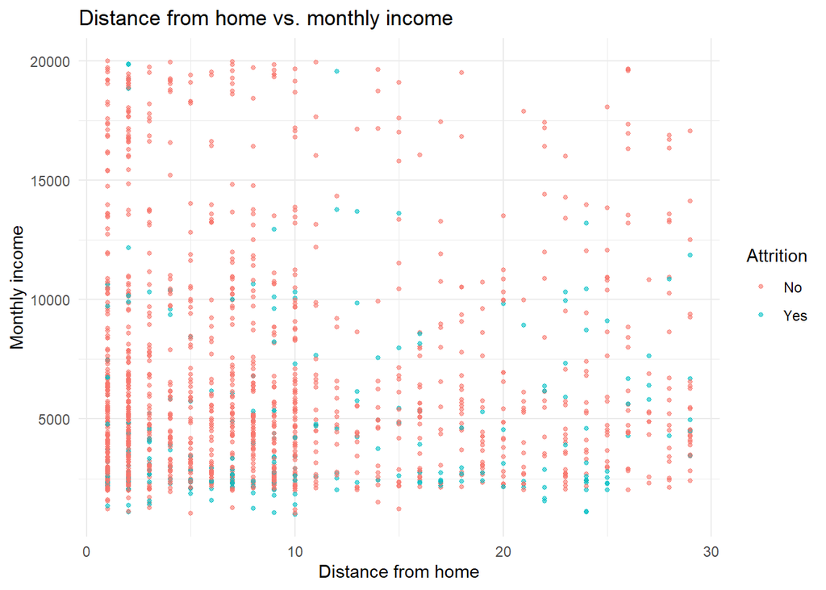

Yes, employees with a long commute seem to be more likely to leave, but it is not as big of a factor as one would expect. It indicates to me that if employees are happy at a job, they will be more willing to commute and unhappy employees will not be convinced to stay by short commute.

### Education field vs monthly income by attrition:

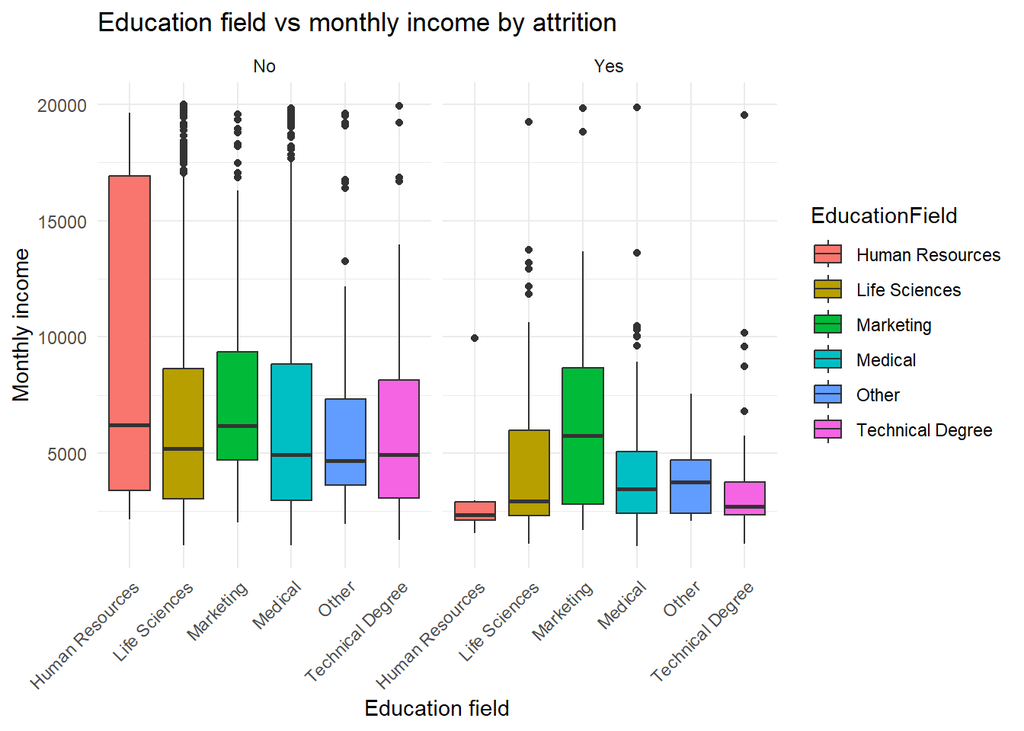

Employees earning below the average salary—especially those in the bottom 25%—are significantly more likely to leave. This suggests that feelings of being undervalued, lack of raises, or limited internal promotions may be key drivers of attrition.

### Boxplot of monthly income by attrition

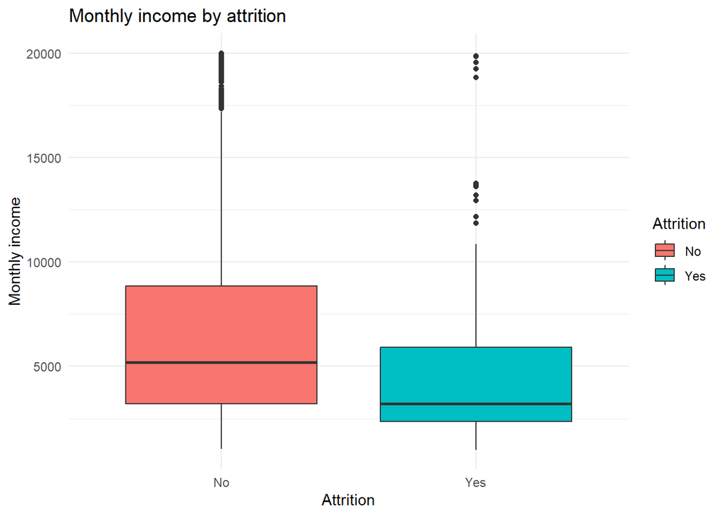

Again, no matter the job, below average pay makes workers feel undervalued and want to leave.

### Are satisfied employees as likely to leave as unhappy ones?

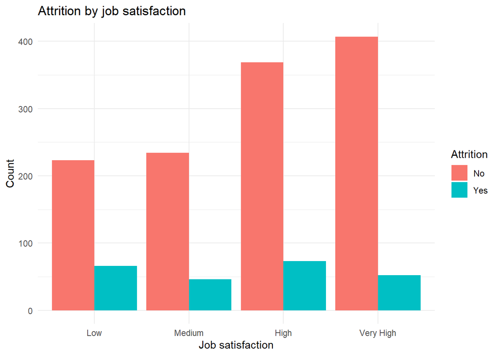

### Age vs monthly income:

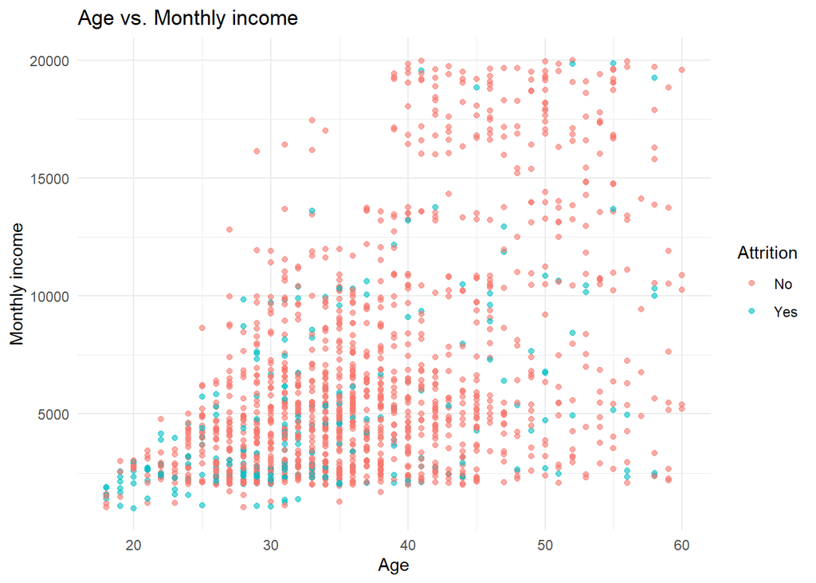

There is a clear (and very obvious) correlation between age and monthly income, with younger people earning less, which is expected, since salaries increase with experience.

### Age vs years at the company:

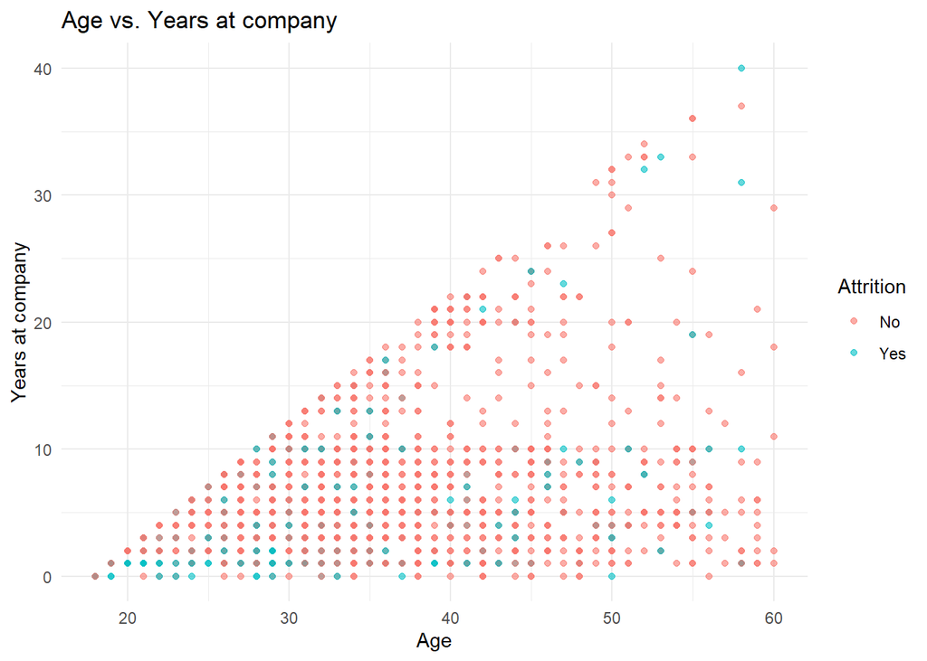

### Years at the company vs monthly income with moving average

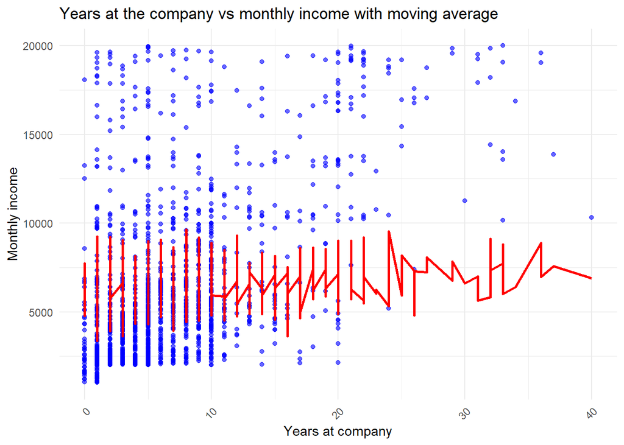

The plot shows the relationship between years at the company and monthly income with a moving average applied, but the result appears unclear due to fluctuations. To better capture the trend, I’ve employed LOESS (Locally Estimated Scatterplot Smoothing), which provides a more flexible and accurate fit to the data.

### LOESS

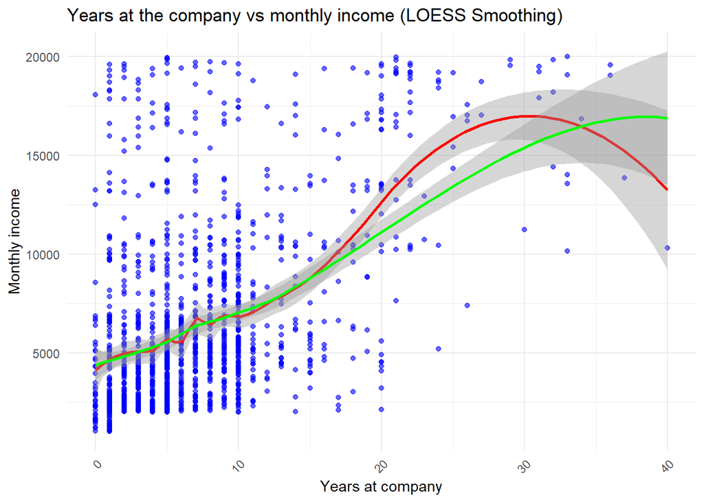

As we can see, monthly income increases with years worked at the company.

### Monthly income vs education level:

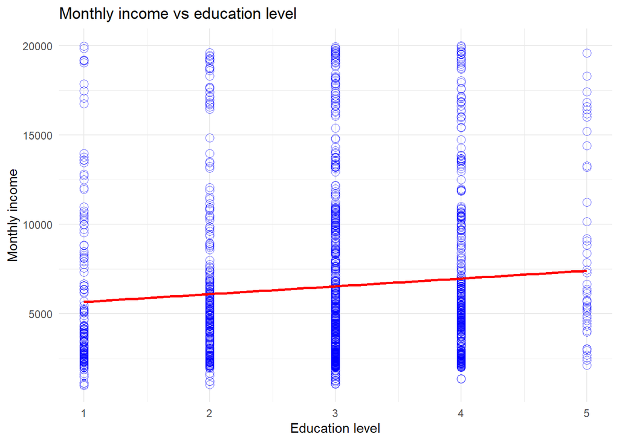

Education level (up to a certain point) does have an impact on montly earnings, but it is actually not as impactful as I thought it would be.

### Monthly income vs attrition

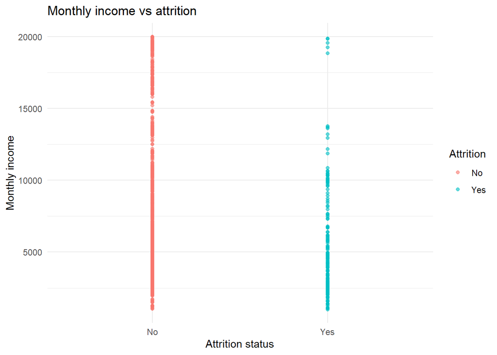

We can see yet again that workers receiving lower than average monthly income will be more likely to leave.

### Analyzing how monthly income relates to job satisfaction and whether employees in different satisfaction categories have different income levels can shed light on employee retention:

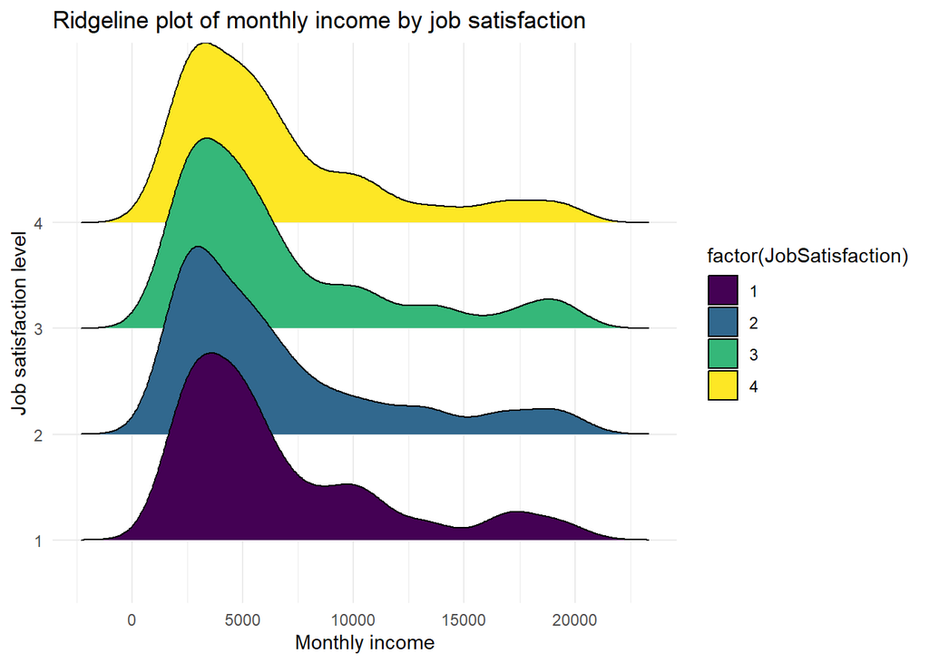

Surprisingly, the income is not a strong indicator of job satisfaction. It is possible that other factors, like workplace culture might be more important.

### Histogram of monthly income:

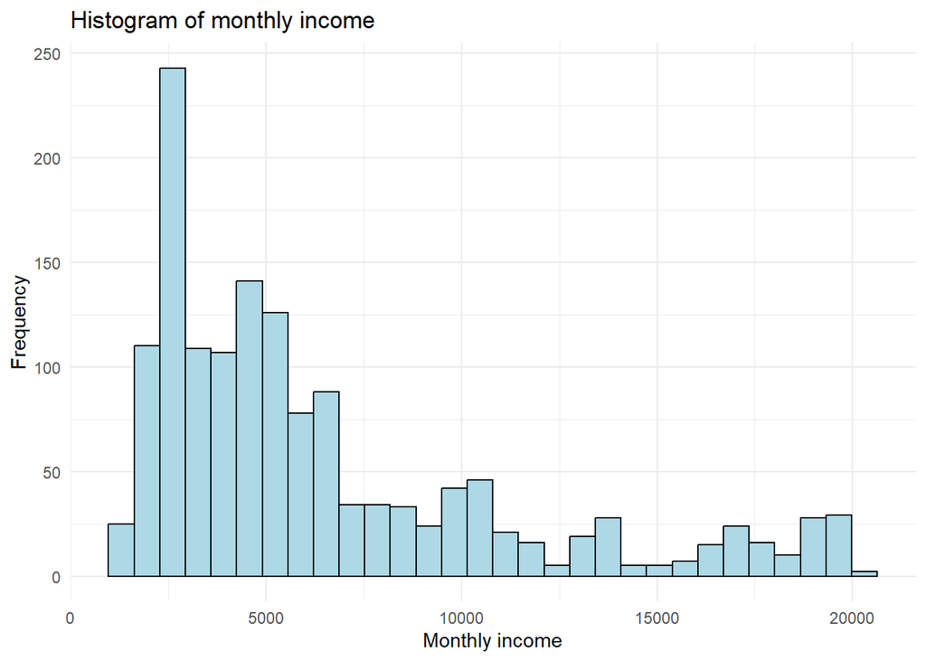

We see that most of the employees make below 7500 per month (and those are the employees most likely to quit).

### Monthly income by education field with confidence intervals:

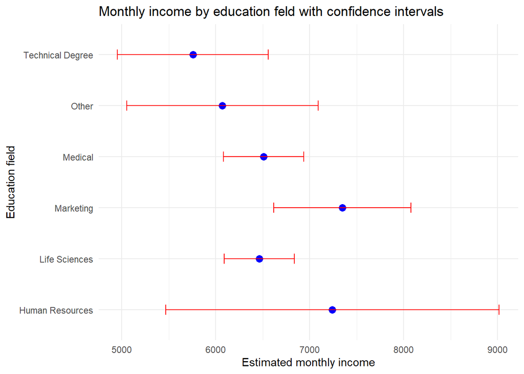

### In conclusion: our analysis reveals that there are several key factors influencing why employees would leave the company. Younger people are more likely to leave, suggesting that the company might struggle with retaining newer employees, by for example hiring externally instead of promoting within the company (but it could also be caused by the fact that younger people change jobs more often in general). Additionally, employees with lower job satisfaction and those earning less are more likely to quit, which indicates that a fair compensation and a good work environment are essential for retaining employees. Our findings emphasize the importance of addressing job satisfaction, career growth opportunities and good compensation to reduce turnover.